# Advanced Data Transformation and Manipulation

# 1 Objectives

This document outlines some advanced data reshaping tasks with `tidyr`. Read more about `dplyr` [here](https://dplyr.tidyverse.org/index.html) and [`tidyr`](https://tidyr.tidyverse.org/) on the tidyverse website, or in the [Data Transformation](https://r4ds.had.co.nz/transform.html) chapter of R for Data Science.

# 2 Materials

View the slides for this section [here](https://mjfrigaard.github.io/csuc-data-journalism/slides.html).

## 2.1 Load packages

`tidyr` is part of the core `tidyverse` packages, so we install and load this meta-package below.

```r
install.packages("tidyverse")
library(tidyverse)
```

# 3 Generating Sequences

## 3.1 `seq()`

We can use the `lubridate::ymd_hm()` function and `seq()` to create a sequence of dates or datetimes.

### 3.1.1 exercise

Create a sequence of datetimes from midnight on `"2020-05-01"` until midnight on `"2020-05-02"`, separated by `"hour"`.

```r
may_hours <- seq(lubridate::ymd_hm("__________ 0:00"),
    lubridate::ymd_hm("__________ 0:00"),
    by = "____")
head(may_hours, _)
head(may_hours, _)
```

### 3.1.2 solution

See below:

```r
may_hours <- seq(lubridate::ymd_hm("2020-05-01 0:00"),
    lubridate::ymd_hm("2020-05-02 0:00"),
    by = "hour")
head(may_hours, 3)
```

```
## [1] "2020-05-01 00:00:00 UTC" "2020-05-01 01:00:00 UTC"
## [3] "2020-05-01 02:00:00 UTC"
```

```r
head(may_hours, 3)
```

```
## [1] "2020-05-01 00:00:00 UTC" "2020-05-01 01:00:00 UTC"
## [3] "2020-05-01 02:00:00 UTC"
```

## 3.2 `tidyr::full_seq()`

The `tidyr::full_seq()` works similar to `seq()`–it takes a vector (`x`), finds the `min` and `max` value, then generates the ‘full sequence’ of values, spaced out by the `period` argument.

Consider the vector `c(1, 3, 8, 10, 15)`.

```r
tidyr::full_seq(x = c(1, 3, 8, 10, 15), period = 1)
```

```
##  [1]  1  2  3  4  5  6  7  8  9 10 11 12 13 14 15
```

### 3.2.1 exercise

Create a vector of two June dates:

1. 8am on June 1, 2020.
2. 5pm on June 1, 2020.

```r
jun_dates <- c(lubridate::ymd_hm("2020-__-__ __:__"),
               lubridate::ymd_hm("2020-__-__ __:__"))
jun_dates
```

### 3.2.2 solution

See below:

```r
jun_dates <- c(lubridate::ymd_hm("2020-06-01 08:00"),
               lubridate::ymd_hm("2020-06-01 17:00"))
jun_dates
```

```
## [1] "2020-06-01 08:00:00 UTC" "2020-06-01 17:00:00 UTC"
```

### 3.2.3 exercise

Create a full sequence of June datetimes, starting at 8am June 1, 2020 and ending at 5pm June 1, 2020. Each value should be 15 min apart.

```r
head(
  full_seq(x = ________,
           period = ___)
)
```

### 3.2.4 solution

15 min x 60 seconds = 900 seconds.

```r
head(
  full_seq(x = jun_dates,
           period = 900)
)
```

```
## [1] "2020-06-01 08:00:00 UTC" "2020-06-01 08:15:00 UTC"
## [3] "2020-06-01 08:30:00 UTC" "2020-06-01 08:45:00 UTC"
## [5] "2020-06-01 09:00:00 UTC" "2020-06-01 09:15:00 UTC"
```

# 4 Identify Missing Values

We’re going to use `expand_grid()` and `anti_join()` to find the missing values in the `VisitNAData` data frame.

```r
VisitNAData <- readr::read_csv(file = "https://bit.ly/36tnN55")
VisitNAData
```

| visit_type | date |
| --- | --- |
| Consult | 2020-05-01 00:00:00 |
| Lab | 2020-05-01 01:00:00 |
| Clinic | 2020-05-01 02:00:00 |
| Pharmacy | 2020-05-01 03:00:00 |
| Consult | 2020-05-01 04:00:00 |
| Lab | 2020-05-01 05:00:00 |
| Clinic | 2020-05-01 06:00:00 |
| Pharmacy | 2020-05-01 07:00:00 |
| Consult | 2020-05-01 08:00:00 |
| Lab | 2020-05-01 09:00:00 |

[output cut: 90 more lines]

## 4.1 Creating List of Unique Values

Create a list of possible visit types (`"Consult"`, `"Lab"`, `"Clinic"`, `"Pharmacy"`) and store it in `visits`.

### 4.1.1 exercise

```r
______ <- c("______", "___", "_______", "__________")
```

### 4.1.2 solution

See below:

```r
visits <- c("Consult", "Lab", "Clinic", "Pharmacy")
```

## 4.2 Expanding Data

Create a data frame with all possible combinations of `may_hours` and `visits`. Name the columns `date` and `visit_type`.

### 4.2.1 exercise

```r
FullDateVisit <- expand_grid(
  date = _______,
  visit_type = ________)
head(FullDateVisit)
```

### 4.2.2 solution

See below:

```r
FullDateVisit <- expand_grid(
  date = may_hours,
  visit_type = visits)
head(FullDateVisit)
```

| date | visit_type |
| --- | --- |
| 2020-05-01 00:00:00 | Consult |
| 2020-05-01 00:00:00 | Lab |
| 2020-05-01 00:00:00 | Clinic |
| 2020-05-01 00:00:00 | Pharmacy |
| 2020-05-01 01:00:00 | Consult |
| 2020-05-01 01:00:00 | Lab |

## 4.3 Anti-join

Check how many missing `visit_type`s there are with `dplyr::count()`

```r
VisitNAData %>%
  count(visit_type)
```

| visit_type | n |
| --- | --- |
| Clinic | 23 |
| Consult | 23 |
| Lab | 25 |
| Pharmacy | 21 |
| NA | 8 |

### 4.3.1 exercise

Join the `FullDateVisit` to `VisitNAData` with an anti-join, using `date` and `visit_type` as the id.

```r
anti_join(x = FullDateVisit,
          y = ___________,
          by = c("date", "visit_type"))
```

### 4.3.2 solution

These are the eight values that are missing from the `count()` output.

```r
anti_join(x = FullDateVisit,
          y = VisitNAData,
          by = c("date", "visit_type"))
```

| date | visit_type |
| --- | --- |
| 2020-05-01 04:00:00 | Pharmacy |
| 2020-05-01 05:00:00 | Pharmacy |
| 2020-05-01 09:00:00 | Clinic |
| 2020-05-01 13:00:00 | Clinic |
| 2020-05-01 14:00:00 | Consult |
| 2020-05-01 15:00:00 | Pharmacy |
| 2020-05-01 17:00:00 | Consult |
| 2020-05-01 19:00:00 | Pharmacy |

# 5 Complete Missing Values

Let’s return to our lab data from the previous exercises. Assume we have an data frame with an incomplete list of lab counts.

```r
LabCounts <- tibble::tribble(
  ~lab, ~lab_count,
  "Albumin", 10L,
  "Potassium, Whole Blood", 8L,
  "% Hemoglobin A1c", 29L)
LabCounts
```

| lab | lab_count |
| --- | --- |
| Albumin | 10 |
| Potassium, Whole Blood | 8 |
| % Hemoglobin A1c | 29 |

## 5.1 Complete

One lab is missing from this list (`eGFR`), so we will make a vector with the known labs that are supposed to be the `LabCounts` data frame.

### 5.1.1 exercise

```r
labs_list <- c("Albumin", "Potassium, Whole Blood",
               "% Hemoglobin A1c", "____")
labs_list
```

### 5.1.2 solution

```r
labs_list <- c("Albumin", "Potassium, Whole Blood",
               "% Hemoglobin A1c", "eGFR")
labs_list
```

```
## [1] "Albumin"                "Potassium, Whole Blood" "% Hemoglobin A1c"
## [4] "eGFR"
```

### 5.1.3 exercise

Use `complete()` to fill in the missing `lab_count` for `eGFR`.

```r
LabCounts %>%
  complete(
    lab = ________,
    fill = list(lab_count = __))
```

### 5.1.4 solution

See below:

```r
LabCounts %>%
  complete(
    lab = labs_list,
    fill = list(lab_count = NA))
```

| lab | lab_count |
| --- | --- |
| % Hemoglobin A1c | 29 |
| Albumin | 10 |
| eGFR | NA |
| Potassium, Whole Blood | 8 |

### 5.1.5 exercise

Use `complete()` again, but use `list()` to make the missing `lab_count` values `0`.

```r
LabCounts %>%
  complete(
    lab = ________,
    fill = list(lab_count = __))
```

### 5.1.6 solution

Note the `L` behind the `0`.

```r
LabCounts %>%
  complete(
    lab = labs_list,
    fill = list(lab_count = 0L))
```

| lab | lab_count |
| --- | --- |
| % Hemoglobin A1c | 29 |
| Albumin | 10 |
| eGFR | 0 |
| Potassium, Whole Blood | 8 |

# 6 Combine all three!

We’re going to combine the use of `pivot_longer()`, `complete()`, and `full_seq()`.

## 6.1 `difftime`

```r
Infected <- read_csv("https://bit.ly/33zp4Fw")
Infected
```

| patient | infection_start | infection_end |
| --- | --- | --- |
| P1 | 2020-03-11 | 2020-06-25 |
| P2 | 2020-03-22 | 2020-07-16 |
| P3 | 2020-03-05 | 2020-07-14 |
| P4 | 2020-03-29 | 2020-07-15 |
| P5 | 2020-03-19 | 2020-06-20 |
| P6 | 2020-03-06 | 2020-06-28 |
| P7 | 2020-03-26 | 2020-07-30 |
| P8 | 2020-03-16 | 2020-07-01 |
| P9 | 2020-03-15 | 2020-07-11 |
| P10 | 2020-03-27 | 2020-08-01 |

[output cut: 10 more lines]

### 6.1.1 exercise

What if we wanted to know the number of days between `infection_start` and `infection_end`? One way to do this is with `difftime()`. It takes two datetime values, and the units the differences should be in (`"days"`)

Calculate the number of days between `infection_start` and `infection_end` in days.

```r
Infected %>%
  mutate(infected_days = difftime(time1 = _____________,
                                  time2 = _____________,
                                  units = "days"))
```

### 6.1.2 solution

See below:

```r
Infected %>%
  mutate(infected_days = difftime(time1 = infection_end,
                                  time2 = infection_start,
                                  units = "days"))
```

| patient | infection_start | infection_end | infected_days |
| --- | --- | --- | --- |
| P1 | 2020-03-11 | 2020-06-25 | 106 days |
| P2 | 2020-03-22 | 2020-07-16 | 116 days |
| P3 | 2020-03-05 | 2020-07-14 | 131 days |
| P4 | 2020-03-29 | 2020-07-15 | 108 days |
| P5 | 2020-03-19 | 2020-06-20 | 93 days |
| P6 | 2020-03-06 | 2020-06-28 | 114 days |
| P7 | 2020-03-26 | 2020-07-30 | 126 days |
| P8 | 2020-03-16 | 2020-07-01 | 107 days |
| P9 | 2020-03-15 | 2020-07-11 | 118 days |
| P10 | 2020-03-27 | 2020-08-01 | 127 days |

[output cut: 10 more lines]

## 6.2 `pivot_longer`

The previous example gave us the total number of days for each patient’s infection, but what if we wanted to calculate a running total of infected days for each patient? We would have to reshape the `Infected` dataset into a longer format.

### 6.2.1 exercise

Pivot the two date columns in the `Infected` dataset, assign the names to `"infection_status"`, and the values to `"date".`

```r
Infected %>%
  pivot_longer(-patient,
  names_to = "_____________",
  values_to = "____")
```

### 6.2.2 solution

See below:

```r
Infected %>%
  pivot_longer(-patient,
  names_to = "infection_status",
  values_to = "date")
```

| patient | infection_status | date |
| --- | --- | --- |
| P1 | infection_start | 2020-03-11 |
| P1 | infection_end | 2020-06-25 |
| P2 | infection_start | 2020-03-22 |
| P2 | infection_end | 2020-07-16 |
| P3 | infection_start | 2020-03-05 |
| P3 | infection_end | 2020-07-14 |
| P4 | infection_start | 2020-03-29 |
| P4 | infection_end | 2020-07-15 |
| P5 | infection_start | 2020-03-19 |
| P5 | infection_end | 2020-06-20 |

[output cut: 30 more lines]

## 6.3 `complete`

Now that we have `date` and `infection_status` in a long format, we can start calculating the number of days between `infection_start` and `infection_end`.

### 6.3.1 exercise

Group the data by `patient`, then `complete()` the dataset:

- assign `patient` to `patient`
- set `date` using the `full_seq()` function to fill in the missing days between the `infection_start` and `infection_end` dates
- use the `fill` argument to replace the missing values in `infection_status` as `"infected"`.

```r
Infected %>%
  pivot_longer(-patient,
  names_to = "infection_status",
  values_to = "date") %>%
  group_by(_________) %>%
  complete(patient = _______,
           date = full_seq(____, period = 1),
           fill = list(infection_status = "___________"))
```

### 6.3.2 solution

See below:

```r
Infected %>%
  pivot_longer(-patient,
  names_to = "infection_status",
  values_to = "date") %>%
  group_by(patient) %>%
  complete(patient = patient,
           date = full_seq(date, period = 1),
           fill = list(infection_status = "infected")) -> InfectedLong
InfectedLong
```

| patient | date | infection_status |
| --- | --- | --- |
| P1 | 2020-03-11 | infection_start |
| P1 | 2020-03-12 | infected |
| P1 | 2020-03-13 | infected |
| P1 | 2020-03-14 | infected |
| P1 | 2020-03-15 | infected |
| P1 | 2020-03-16 | infected |
| P1 | 2020-03-17 | infected |
| P1 | 2020-03-18 | infected |
| P1 | 2020-03-19 | infected |
| P1 | 2020-03-20 | infected |

[output cut: 2214 more lines]

## 6.4 `lag()`

In order to calculate the running total of infected days, we’re going to combine `difftime()`, `if_else()`, and `cumsum()`.

### 6.4.1 exercise

We’re going to start by using `difftime()` and `lag()` to calculate the difference between `date` and `lag(x = date, n = 1)`.

Instead of using `"days"`, we’re going to pass the output to `as.numeric()` so it’s converted to a `double`.

```r
InfectedLong %>%
  mutate(
    day_diff0 = as.numeric(difftime(time1 = ____,
                                    time2 = lag(x = ____,
                                                n = 1))))
```

### 6.4.2 soltution

See below:

```r
InfectedLong %>%
  mutate(
    day_diff0 = as.numeric(difftime(time1 = date,
                                   time2 = lag(x = date,
                                               n = 1))))
```

| patient | date | infection_status | day_diff0 |
| --- | --- | --- | --- |
| P1 | 2020-03-11 | infection_start | NA |
| P1 | 2020-03-12 | infected | 1 |
| P1 | 2020-03-13 | infected | 1 |
| P1 | 2020-03-14 | infected | 1 |
| P1 | 2020-03-15 | infected | 1 |
| P1 | 2020-03-16 | infected | 1 |
| P1 | 2020-03-17 | infected | 1 |
| P1 | 2020-03-18 | infected | 1 |
| P1 | 2020-03-19 | infected | 1 |
| P1 | 2020-03-20 | infected | 1 |

[output cut: 2214 more lines]

## 6.5 `if_else()`

### 6.5.1 exercise

Create `day_diff` and use `dplyr::if_else()` to replace the `NA` in `day_diff0`.

`dplyr::if_else()` takes a logical condition, the desired result if it is `true`, and the desired result if it is `false`

```r
InfectedLong %>%
  mutate(
    day_diff0 = as.numeric(difftime(time1 = date,
                                   time2 = lag(x = date,
                                               n = 1))),
    # replace missing day_diff0 with 0, all else get day_diff0
    day_diff = dplyr::if_else(condition = is.na(________),
                      true = _,
                      false = ________))
```

### 6.5.2 solution

See below:

```r
InfectedLong %>%
  mutate(
    day_diff0 = as.numeric(difftime(time1 = date,
                                   time2 = lag(x = date,
                                               n = 1))),
    day_diff = dplyr::if_else(condition = is.na(day_diff0),
                      true = 0,
                      false = day_diff0))
```

| patient | date | infection_status | day_diff0 | day_diff |
| --- | --- | --- | --- | --- |
| P1 | 2020-03-11 | infection_start | NA | 0 |
| P1 | 2020-03-12 | infected | 1 | 1 |
| P1 | 2020-03-13 | infected | 1 | 1 |
| P1 | 2020-03-14 | infected | 1 | 1 |
| P1 | 2020-03-15 | infected | 1 | 1 |
| P1 | 2020-03-16 | infected | 1 | 1 |
| P1 | 2020-03-17 | infected | 1 | 1 |
| P1 | 2020-03-18 | infected | 1 | 1 |
| P1 | 2020-03-19 | infected | 1 | 1 |
| P1 | 2020-03-20 | infected | 1 | 1 |

[output cut: 2214 more lines]

No we have `0`’s instead of `NA`s.

## 6.6 `cumsum()`

### 6.6.1 exercise

Finally we have a numerical variable we can add up to get the number of days infected at each day in `date`. Here we will use the `cumsum()` function (cumulative sum) to get the running total number of days infected per `patient` (recall the dataset is still grouped by `patient`).

Create `total_inf_days` by getting the `cumsum()` of a numerically formatted `day_diff` column.

```r
InfectedLong %>%
  mutate(
    day_diff0 = as.numeric(difftime(time1 = date,
                                   time2 = lag(x = date,
                                               n = 1))),
     day_diff = dplyr::if_else(condition = is.na(day_diff0),
                      true = 0,
                      false = day_diff0),

     _____________ = cumsum(as.numeric(________)))
```

### 6.6.2 solution

See below

```r
InfectedLong %>%
  mutate(
    day_diff0 = as.numeric(difftime(time1 = date,
                                   time2 = lag(x = date,
                                               n = 1))),
     day_diff = dplyr::if_else(condition = is.na(day_diff0),
                      true = 0,
                      false = day_diff0),

   total_inf_days = cumsum(as.numeric(day_diff)))
```

| patient | date | infection_status | day_diff0 | day_diff | total_inf_days |
| --- | --- | --- | --- | --- | --- |
| P1 | 2020-03-11 | infection_start | NA | 0 | 0 |
| P1 | 2020-03-12 | infected | 1 | 1 | 1 |
| P1 | 2020-03-13 | infected | 1 | 1 | 2 |
| P1 | 2020-03-14 | infected | 1 | 1 | 3 |
| P1 | 2020-03-15 | infected | 1 | 1 | 4 |
| P1 | 2020-03-16 | infected | 1 | 1 | 5 |
| P1 | 2020-03-17 | infected | 1 | 1 | 6 |
| P1 | 2020-03-18 | infected | 1 | 1 | 7 |
| P1 | 2020-03-19 | infected | 1 | 1 | 8 |
| P1 | 2020-03-20 | infected | 1 | 1 | 9 |

[output cut: 2214 more lines]

## 6.7 Clean Up

These last few steps are for cleaning up our `InfectedLong` by removing the underscore (`_`) from `infection_status`, `ungrouping()` the data, and dropping the intermediate `day_diff0` and `day_diff` columns.

### 6.7.1 exercise

```r
InfectedLong %>%
  mutate(
    day_diff0 = as.numeric(difftime(time1 = date,
                                   time2 = lag(x = date,
                                               n = 1))),
     day_diff = dplyr::if_else(condition = is.na(day_diff0),
                      true = 0,
                      false = day_diff0),

   total_inf_days = cumsum(as.numeric(day_diff)),

   infection_status = str_replace_all(string = __________________,
                                      pattern = ___,
                                      replacement = ___)) %>%
  ________() %>%
  select(-c(_________, _________))
```

### 6.7.2 solution

See below.

```r
InfectedLong %>%
  mutate(
    day_diff0 = as.numeric(difftime(time1 = date,
                                   time2 = lag(x = date,
                                               n = 1))),
     day_diff = dplyr::if_else(condition = is.na(day_diff0),
                      true = 0,
                      false = day_diff0),

   total_inf_days = cumsum(as.numeric(day_diff)),

   infection_status = str_replace_all(string = infection_status,
                                      pattern = "_",
                                      replacement = " ")) %>%
  ungroup() %>%
  # remove intermediate columns
  select(-c(day_diff0, day_diff)) -> InfectedLong

InfectedLong
```

| patient | date | infection_status | total_inf_days |
| --- | --- | --- | --- |
| P1 | 2020-03-11 | infection start | 0 |
| P1 | 2020-03-12 | infected | 1 |
| P1 | 2020-03-13 | infected | 2 |
| P1 | 2020-03-14 | infected | 3 |
| P1 | 2020-03-15 | infected | 4 |
| P1 | 2020-03-16 | infected | 5 |
| P1 | 2020-03-17 | infected | 6 |
| P1 | 2020-03-18 | infected | 7 |
| P1 | 2020-03-19 | infected | 8 |
| P1 | 2020-03-20 | infected | 9 |

[output cut: 2214 more lines]

### 6.7.3 Plotting Counts

Now we can count the number of times each `date` occurs and plot if over `date`.

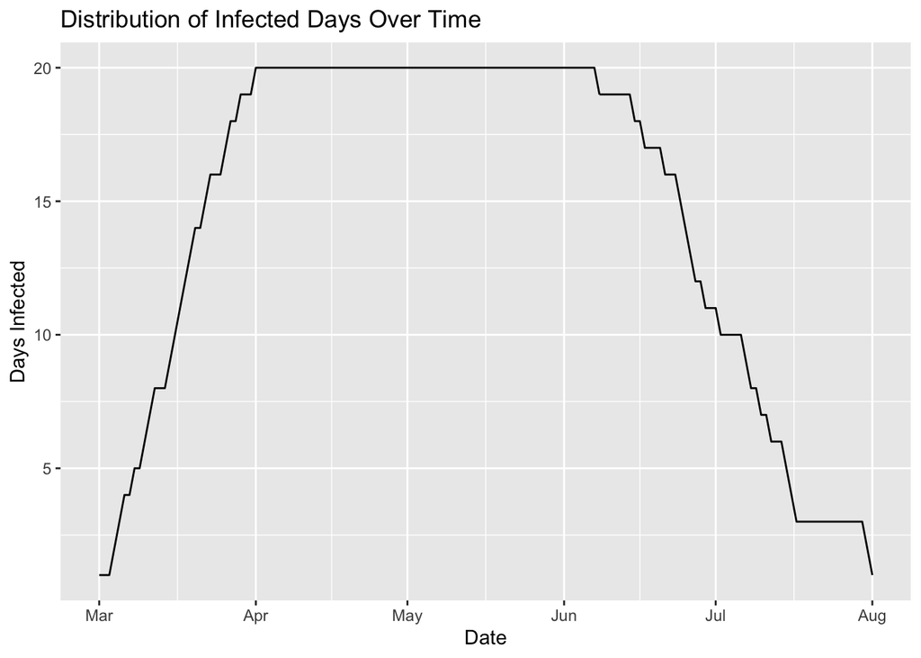

```r
InfectedLong %>%
  count(date, name = "days_inf") %>%
  ggplot(aes(x = date, y = days_inf)) +
  geom_line() +
  labs(x = "Date", y = "Days Infected",
       title = "Distribution of Infected Days Over Time")
```